# Latihan Pertemuan 4 Prak

G1401231072 - Aurisa Putri Hawin Yusima

2025-09-25

# Proses MA (2)

```r
library(TSA)
set.seed(1072)
```

## Pembangkitan Model

```r
n_data <- 300
theta1 <- 0.4
theta2 <- 0.6
mean_ma <- 0
sd_noise <- 1
```

### arima.sim

```r
ma2_sim <- arima.sim(model = list(ma = c(theta1, theta2)), n = n_data, mean = mean_ma, sd = sd_noise)
```

### Manual

```r
epsilon <- rnorm(n_data + 2, mean = mean_ma, sd = sd_noise) # Perlu 2 data awal
ma2_manual <- numeric(n_data)
for (t in 1:n_data) {
  ma2_manual[t] <- epsilon[t + 2] + theta1 * epsilon[t + 1] + theta2 * epsilon[t]
}
ma2_manual <- ts(ma2_manual)
```

## Plot Time Series

```r
par(mfrow = c(2, 2))

plot(ma2_sim, main = "Plot Time Series MA(2)", ylab = "Yt", xlab = "Waktu")
abline(h = 0, col = "red", lty = 2)

acf(ma2_sim, main = "Plot ACF", lag.max = 20)

pacf(ma2_sim, main = "Plot PACF", lag.max = 20)

eacf(ma2_sim)
```

```
## AR/MA
##   0 1 2 3 4 5 6 7 8 9 10 11 12 13
## 0 x x x o x o o o o o o  o  o  o
## 1 x x o o x o o o o o x  o  o  o
## 2 x x o x o o o o o o o  o  o  o
## 3 x x o x x o o o o o o  o  o  o
## 4 x x o x o o o o o o o  o  o  o
## 5 x x x x x x x o o o o  o  o  o
## 6 x x x o o x o o o o o  o  o  o
## 7 x o x o o x o o o o o  o  o  o
```

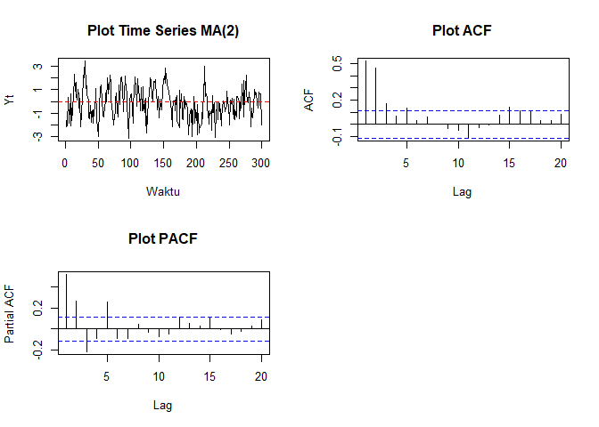

```r
par(mfrow = c(1, 1))
```

## Scatterplot

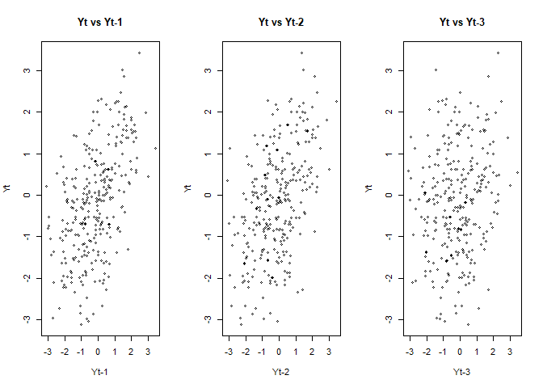

```r
par(mfrow = c(1, 3))

# Yt vs Yt-1
plot(y = ma2_sim, x = lag(ma2_sim, -1), main = "Yt vs Yt-1", xlab = "Yt-1", ylab = "Yt")

# Yt vs Yt-2
plot(y = ma2_sim, x = lag(ma2_sim, -2), main = "Yt vs Yt-2", xlab = "Yt-2", ylab = "Yt")

# Yt vs Yt-3
plot(y = ma2_sim, x = lag(ma2_sim, -3), main = "Yt vs Yt-3", xlab = "Yt-3", ylab = "Yt")
```

```r
par(mfrow = c(1, 1))
```

Interpretasi: - Plot Yt vs Yt-1 dan YT cs YT-2 menunjukkan adanya pola hubungan lemah - Plot YT vs YT-3 menunjukkan tidak adanya korelasi

## Autokorelasi

### Autokorelasi Data Bangkitan

```r
sample_acf <- acf(ma2_sim, plot = FALSE, lag.max = 5)
print("Autokorelasi dari Data Bangkitan:")
```

```
## [1] "Autokorelasi dari Data Bangkitan:"
```

```r
print(sample_acf$acf)
```

```
## , , 1
##
##            [,1]
## [1,] 0.51921258
## [2,] 0.46643980
## [3,] 0.17076852
## [4,] 0.06871099
## [5,] 0.13318761
```

### Autokorelasi Teoritis

```r
gamma0 <- (1 + theta1^2 + theta2^2) * sd_noise^2
gamma1 <- (theta1 + theta1 * theta2) * sd_noise^2
gamma2 <- theta2 * sd_noise^2

rho1_teoritis <- gamma1 / gamma0
rho2_teoritis <- gamma2 / gamma0
rho3_teoritis <- 0

print("Autokorelasi Teoritis:")
```

```
## [1] "Autokorelasi Teoritis:"
```

```r
cat(sprintf("Rho(1) = %.4f\n", rho1_teoritis))
```

```
## Rho(1) = 0.4211
```

```r
cat(sprintf("Rho(2) = %.4f\n", rho2_teoritis))
```

```
## Rho(2) = 0.3947
```

```r
cat(sprintf("Rho(3) = %.4f\n", rho3_teoritis))
```

```
## Rho(3) = 0.0000
```

# Proses AR(2)

Cek kestasioneran model $\phi\_1 + \phi\_2 = 0.5 + 0.2 = 0.7 < 1$ $\phi\_2 - \phi\_1 = 0.2 - 0.5 = -0.3 < 1$ $|\phi\_2| = |0.2| < 1$

Terbukti semua model stasioner

```r
library(TSA)
```

```r
set.seed(1072)
```

## Pembangkitan Model

```r
n_data <- 300
phi1 <- 0.5
phi2 <- 0.2
mean_ar <- 0
```

### arima.sim

```r
ar2_sim <- arima.sim(model = list(ar = c(phi1, phi2)), n = n_data, mean = mean_ar)
```

### Manual

```r
burn_in <- 100
n_total <- n_data + burn_in
epsilon <- rnorm(n_total, mean = 0, sd = 1)
ar2_manual <- numeric(n_total)

# Y1 dan Y2
ar2_manual[1] <- epsilon[1]
ar2_manual[2] <- phi1 * ar2_manual[1] + epsilon[2]

for (t in 3:n_total) {
  ar2_manual[t] <- phi1 * ar2_manual[t - 1] + phi2 * ar2_manual[t - 2] + epsilon[t]
}

ar2_manual_final <- ts(ar2_manual[(burn_in + 1):n_total])
```

## Plot Time Series, ACF, PACF, EACF

```r
par(mfrow = c(2, 2))

plot(ar2_sim, main = "Plot Time Series AR(2)", ylab = "Yt", xlab = "Waktu")
abline(h = 0, col = "red", lty = 2)

acf(ar2_sim, main = "Plot ACF", lag.max = 20)

pacf(ar2_sim, main = "Plot PACF", lag.max = 20)

eacf(ar2_sim)
```

```
## AR/MA
##   0 1 2 3 4 5 6 7 8 9 10 11 12 13
## 0 x x x x x x x x o o o  o  o  o
## 1 x o o o o o o o o o o  o  o  o
## 2 o o o o o o o o o o o  o  o  o
## 3 x x o o o o o o o o o  o  o  o
## 4 x x x o o o o o o o o  o  o  o
## 5 x x o o o o o o o o o  o  o  o
## 6 o x o x o o o o o o o  o  o  o
## 7 o x x x o o o o o o o  o  o  o
```

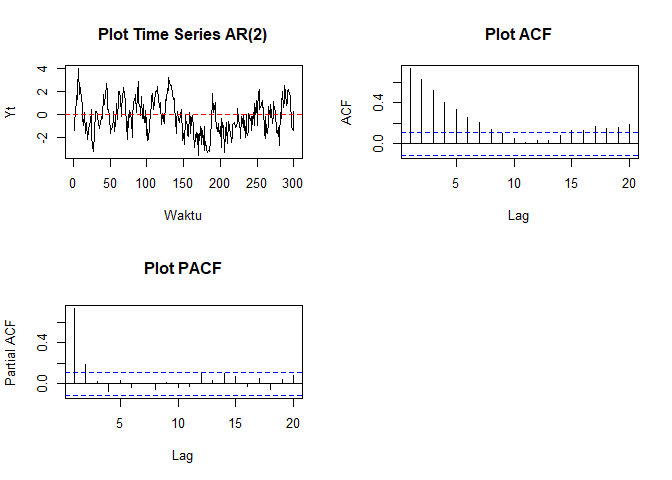

```r
par(mfrow = c(1, 1))
```

Interpretasi: - Plot time series menunjukkan data fluktuasi di sekitar 0 yang berarti data stasioner - Plot ACF menunjukkan tails off - Plot PACF signifikan pada lag 1 dan 2 - PlotEACF menunjukkan AR ordo 2 dan MA ordo 0

## Scatterplot

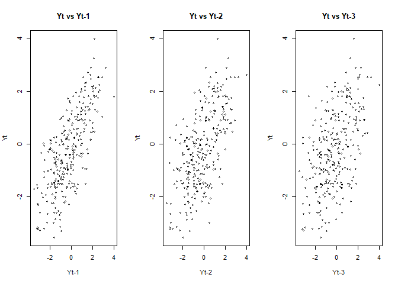

```r
par(mfrow = c(1, 3))

# Yt vs Yt-1
plot(y = ar2_sim, x = lag(ar2_sim, -1), main = "Yt vs Yt-1", xlab = "Yt-1", ylab = "Yt")

# Yt vs Yt-2
plot(y = ar2_sim, x = lag(ar2_sim, -2), main = "Yt vs Yt-2", xlab = "Yt-2", ylab = "Yt")

# Yt vs Yt-3
plot(y = ar2_sim, x = lag(ar2_sim, -3), main = "Yt vs Yt-3", xlab = "Yt-3", ylab = "Yt")
```

```r
par(mfrow = c(1, 1))
```

Interpretasi: - Plot Yt vs Yt-1 dan Yt vs Yt-2 menunjukkan pola hubungan linier positif yang melemah di plot Yt vs Yt-3

## Autokorelasi

### Autokorelasi Data Bangkitan

```r
sample_acf2 <- acf(ar2_sim, plot = FALSE, lag.max = 5)
print("Autokorelasi dari Data Bangkitan:")
```

```
## [1] "Autokorelasi dari Data Bangkitan:"
```

```r
print(sample_acf2$acf)
```

```
## , , 1
##
##           [,1]
## [1,] 0.7333797
## [2,] 0.6262819
## [3,] 0.5201041
## [4,] 0.4005566
## [5,] 0.3377427
```

### Autokorelasi Teoritis

```r
rho_teoritis <- numeric(5)
rho_teoritis[1] <- phi1 / (1 - phi2)
rho_teoritis[2] <- phi1 * rho_teoritis[1] + phi2
rho_teoritis[3] <- phi1 * rho_teoritis[2] + phi2 * rho_teoritis[1]
rho_teoritis[4] <- phi1 * rho_teoritis[3] + phi2 * rho_teoritis[2]
rho_teoritis[5] <- phi1 * rho_teoritis[4] + phi2 * rho_teoritis[3]

print("Autokorelasi Teoritis:")
```

```
## [1] "Autokorelasi Teoritis:"
```

```r
print(rho_teoritis)
```

```
## [1] 0.6250000 0.5125000 0.3812500 0.2931250 0.2228125
```

# Proses ARMA (2,2)

Cek kestasioneran dan invertibilitas

```r
check_roots <- function(coeffs, type = "AR") {
  if (type == "AR") {
    poly_coeffs <- c(1, -coeffs)
  } else if (type == "MA") {
    poly_coeffs <- c(1, coeffs)
  } else {
    stop("Tipe model tidak valid. Gunakan 'AR' atau 'MA'.")
  }

  roots <- polyroot(poly_coeffs)
  mod_roots <- Mod(roots)

  cat("Akar-akar Polinom:\n")
  print(roots)
  cat("\n Modulus dari Akar-akar:\n")
  print(mod_roots)

  if (all(mod_roots > 1)) {
    cat(sprintf("\n Semua akar berada di luar lingkaran satuan. Syarat TERPENUHI.\n"))
  } else {
    cat(sprintf("\n Ada akar di dalam atau pada lingkaran satuan. Syarat TIDAK TERPENUHI.\n"))
  }
}
```

Cek stasioner

```r
phi <- c(0.5, 0.2)

check_roots(coeffs = phi, type = "AR")
```

```
## Akar-akar Polinom:
## [1]  1.311738+0i -3.811738+0i
##
##  Modulus dari Akar-akar:
## [1] 1.311738 3.811738
##
##  Semua akar berada di luar lingkaran satuan. Syarat TERPENUHI.
```

Cek invertibilitas

```r
theta <- c(0.4, 0.6)

check_roots(coeffs = theta, type = "MA")
```

```
## Akar-akar Polinom:
## [1] -0.3333333+1.247219i -0.3333333-1.247219i
##
##  Modulus dari Akar-akar:
## [1] 1.290994 1.290994
##
##  Semua akar berada di luar lingkaran satuan. Syarat TERPENUHI.
```

```r
library(TSA)
```

```r
set.seed(1072)
```

## Pembangkitan Model

```r
n_data <- 300
ar_params <- c(0.5, 0.2)
ma_params <- c(0.4, 0.6)
```

## Data Bangkitan

### arima.sim

```r
arma22_sim <- arima.sim(model = list(ar = ar_params, ma = ma_params), n = n_data)
```

### Manual

```r
burn_in <- 100
n_total <- n_data + burn_in

epsilon_arma <- rnorm(n_total)
arma22_manual <- numeric(n_total)

for (t in 3:n_total) {
  arma22_manual[t] <- (phi1 * arma22_manual[t - 1]) +
                      (phi2 * arma22_manual[t - 2]) +
                      epsilon_arma[t] +
                      (theta1 * epsilon_arma[t - 1]) +
                      (theta2 * epsilon_arma[t - 2])
}

arma22_manual_final <- ts(arma22_manual[(burn_in + 1):n_total])
```

## Plot Time Series, ACF, PACF, EACF

```r
par(mfrow = c(2, 2))

# Plot Time Series
plot(arma22_sim, main = "Plot Time Series ARMA(2,2)", ylab = "Yt", xlab = "Waktu")
abline(h = 0, col = "red", lty = 2)

# Plot ACF
acf(arma22_sim, main = "Plot ACF", lag.max = 20)

# Plot PACF
pacf(arma22_sim, main = "Plot PACF", lag.max = 20)

# Plot EACF
eacf(arma22_sim)
```

```
## AR/MA
##   0 1 2 3 4 5 6 7 8 9 10 11 12 13
## 0 x x x x x x x x x o o  o  o  o
## 1 o x o o o o o o o o x  o  o  o
## 2 x x o o o o o o o o o  o  o  o
## 3 x x o o o o o o o o o  o  o  o
## 4 x x x x o o o o o o x  o  o  o
## 5 x x x x o x o o o o o  o  o  o
## 6 x x x o x x o o o o o  o  o  o
## 7 x x x o o x o x o o o  o  o  o
```

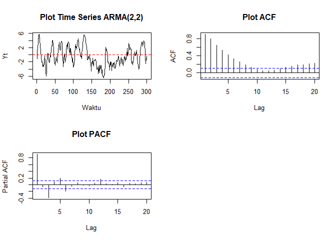

```r
# Mengembalikan layout plot ke default
par(mfrow = c(1, 1))
```

Interpretasi: - Plot EACF menunjukkan model AR 2 dan MA 2 (ARMA 2,2)

## Scatterplot

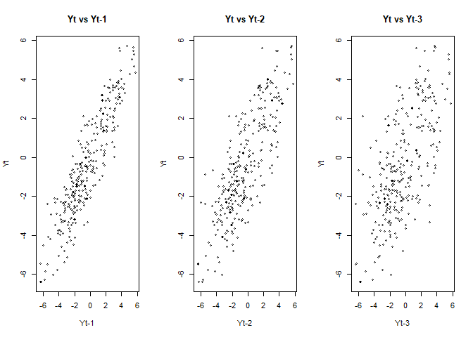

```r
par(mfrow = c(1, 3))

# Yt vs Yt-1
plot(y = arma22_sim, x = lag(arma22_sim, -1), main = "Yt vs Yt-1", xlab = "Yt-1", ylab = "Yt")

# Yt vs Yt-2
plot(y = arma22_sim, x = lag(arma22_sim, -2), main = "Yt vs Yt-2", xlab = "Yt-2", ylab = "Yt")

# Yt vs Yt-3
plot(y = arma22_sim, x = lag(arma22_sim, -3), main = "Yt vs Yt-3", xlab = "Yt-3", ylab = "Yt")
```

```r
par(mfrow = c(1, 1))
```

Interpretasi: - Plot menunjukkan hubungan linier kuat pada lag 1 dan lag 2, kemudian melemah di lag 3

## Autokorelasi

### Data Bangkitan

```r
sample_acf3 <- acf(arma22_sim, plot = FALSE, lag.max = 5)
print("Autokorelasi dari Data Bangkitan:")
```

```
## [1] "Autokorelasi dari Data Bangkitan:"
```

```r
print(sample_acf3$acf)
```

```
## , , 1
##
##           [,1]
## [1,] 0.9059626
## [2,] 0.8092180
## [3,] 0.6535544
## [4,] 0.5280755
## [5,] 0.4295282
```

### Teoritis

```r
phi    <- c(0.5, 0.2)
theta  <- c(0.4, 0.6)
sigma2 <- 1

psi <- numeric(2)
psi[1] <- phi[1] + theta[1]
psi[2] <- theta[2] + phi[1] * psi[1] + phi[2]

cat("Langkah 1: Menghitung Bobot Psi\n")
```

```
## Langkah 1: Menghitung Bobot Psi
```

```r
cat(sprintf("psi_1 = %.2f\n", psi[1]))
```

```
## psi_1 = 0.90
```

```r
cat(sprintf("psi_2 = %.2f\n\n", psi[2]))
```

```
## psi_2 = 1.25
```

```r
A <- matrix(c(
  1,      -phi[1],         -phi[2],
  -phi[1], (1 - phi[2]),    0,
  -phi[2], -phi[1],         1
), nrow = 3, byrow = TRUE)

b <- c(
  sigma2 * (1 + theta[1] * psi[1] + theta[2] * psi[2]),
  sigma2 * (theta[1] + theta[2] * psi[1]),
  sigma2 * theta[2]
)

cat("Langkah 2: Sistem Persamaan Linear\n")
```

```
## Langkah 2: Sistem Persamaan Linear
```

```r
cat("Matriks A:\n")
```

```
## Matriks A:
```

```r
print(A)
```

```
##      [,1] [,2] [,3]
## [1,]  1.0 -0.5 -0.2
## [2,] -0.5  0.8  0.0
## [3,] -0.2 -0.5  1.0
```

```r
cat("\nVektor b:\n")
```

```
##
## Vektor b:
```

```r
print(b)
```

```
## [1] 2.11 0.94 0.60
```

```r
gamma_solusi <- solve(A, b)

cat("\nLangkah 3: Solusi Autokovarians\n")
```

```
##
## Langkah 3: Solusi Autokovarians
```

```r
cat(sprintf("gamma_0 = %.5f\n", gamma_solusi[1]))
```

```
## gamma_0 = 5.01709
```

```r
cat(sprintf("gamma_1 = %.5f\n", gamma_solusi[2]))
```

```
## gamma_1 = 4.31068
```

```r
cat(sprintf("gamma_2 = %.5f\n\n", gamma_solusi[3]))
```

```
## gamma_2 = 3.75876
```

```r
jumlah_lag_total <- 10
rho <- numeric(jumlah_lag_total + 1)

rho[1] <- 1

rho[2] <- gamma_solusi[2] / gamma_solusi[1]
rho[3] <- gamma_solusi[3] / gamma_solusi[1]

for (k in 4:(jumlah_lag_total + 1)) {
  rho[k] <- phi[1] * rho[k - 1] + phi[2] * rho[k - 2]
}

cat("Langkah 4: Hasil Akhir Autokorelasi Teoritis\n")
```

```
## Langkah 4: Hasil Akhir Autokorelasi Teoritis
```

```r
hasil_akhir <- data.frame(
  Lag = 0:jumlah_lag_total,
  Rho_Manual_R = rho
)
print(hasil_akhir, row.names = FALSE)
```

```
##  Lag Rho_Manual_R
##    0   1.00000000
##    1   0.85919932
##    2   0.74919080
##    3   0.54643526
##    4   0.42305579
##    5   0.32081495
##    6   0.24501863
##    7   0.18667231
##    8   0.14233988
##    9   0.10850440
##   10   0.08272018
```